# BL40A2030 Wireless Communication Networks

## Week 1 - Assignment

### Author: Jesse Peltola

```python
import numpy as np
import matplotlib.pyplot as plt
from matplotlib import style
import warnings

style.use("bmh")
warnings.filterwarnings("ignore")
```

### Part I: Theory (40%)

**1. Explain with your own words (1 or 2 paragraphs) the three-layer model presented in the lecture and in [[2]](https://www.ece.rutgers.edu/~marsic/books/CN/book-CN_marsic.pdf).**

**Answer:**

Three-layer model has three layers that are Link layer (Layer 1), Network layer (Layer 2), End-to-end layer (Layer 3). The bottom of the protocol stack is called Link layer which goal is to transport packets between the nodes. There is also a physical layer that is bundled with the link layer. The next upper of the protocal stack is Network layer that is responsible to bridging end hosts across intermediate links. The last one, End-to-end layer, is responsible for bringing the communication-features of the applications together.

**2. Retransmissions via ARQ are important to the system reliability (lower packet error probability) but it has some drawbacks. However, it has some effects in the delay and traffic congestion. Describe with your own words one of the existing trade-offs.** (Hint: If restransmissions are allowed, the packet will stay in *walking* in the network more time).

**Answer:** If retransmission are allowed, the packet will stay in walking in the network more time. The reliability of transmitted packets can be improved by reducing the packet error probability in ARQ. One of the existing trade-offs is *stop-and-wait* where only a signle packet is buffered at the sender as long as it is correctly received. If the corrupted response (ACK/NAK) is received at the sender, it sends NAK back to the receiver.

#### Part II: Jupyter NB experiments (60%)

**3. Analyze a queue system similar to the tutorial considering $\lambda = 3$ and $\mu = 4$ for 2000 time periods.**

- Plot a histogram of the queue sizes.
- Compute the ratio of idle periods (0 elements in the queue) in relation to all time periods.

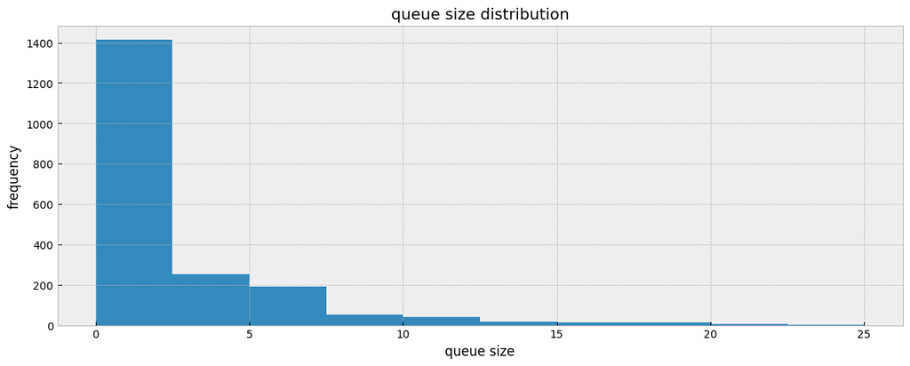

```
Ratio of idle periods is  995 / 2000 = 0.4975
```

```python
#3.

size = 2000

#Arrival
mean = 3
arrival = np.random.poisson(mean, size)

#Queue
mean = 4
service = np.random.poisson(mean, size)

queue = np.zeros(size+1)

for i in range(size):
    if ((arrival[i] - service[i]) + queue[i]) > 0:
        queue[i+1] = max(0, (arrival[i] - service[i]) + queue[i])

plt.figure(figsize=(14, 5))


plt.hist(queue)
plt.xlabel('queue size')
plt.ylabel('frequency')
plt.title('queue size distribution')
plt.grid(True)
plt.show()

#The ratio of periods

ratio = (queue == 0).sum() / size
print("Ratio of idle periods is ", (queue==0).sum(), "/", size, "=", ratio)
```

**4. Analyze a queue system similar to the tutorial considering $\lambda = 4$ and $\mu = 3$ for 2000 time periods.**

- Plot a histogram of the queue sizes.
- Compute the ratio of idle periods (0 elements in the queue) in relation to all time periods.

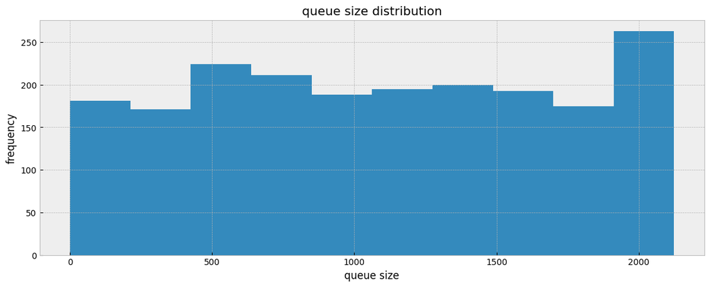

```
Ratio of idle periods is  1 / 2000 = 0.0005
```

```python
#4

size = 2000

#Arrival
mean = 4
arrival = np.random.poisson(mean, size)

#Queue
mean = 3
service = np.random.poisson(mean, size)

queue = np.zeros(size+1)

for i in range(size):
    if ((arrival[i] - service[i]) + queue[i]) > 0:
        queue[i+1] = max(0, (arrival[i] - service[i]) + queue[i])

plt.figure(figsize=(14, 5))


plt.hist(queue)
plt.xlabel('queue size')
plt.ylabel('frequency')
plt.title('queue size distribution')
plt.grid(True)
plt.show()

#The ratio of periods

ratio = (queue == 0).sum() / size
print("Ratio of idle periods is ", (queue==0).sum(), "/", size, "=", ratio)
```

**5. Analyze a queue system similar to the tutorial considering $\lambda = 3$ and $\mu = 3$ for 2000 time periods.**

- Plot a histogram of the queue sizes.
- Compute the ratio of idle periods (0 elements in the queue) in relation to all time periods.

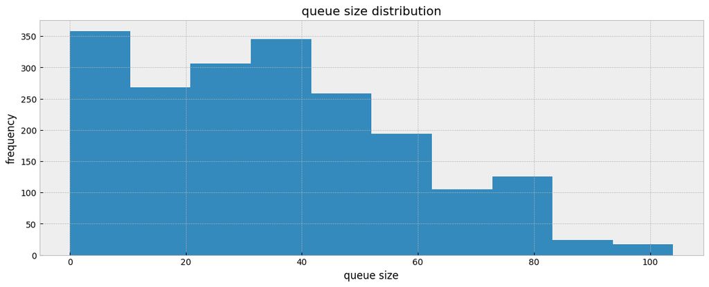

```
Ratio of idle periods is  81 / 2000 = 0.0405
```

```python
#5

size = 2000

#Arrival
mean = 3
arrival = np.random.poisson(mean, size)

#Queue
mean = 3
service = np.random.poisson(mean, size)

queue = np.zeros(size+1)

for i in range(size):
    if ((arrival[i] - service[i]) + queue[i]) > 0:
        queue[i+1] = max(0, (arrival[i] - service[i]) + queue[i])

plt.figure(figsize=(14, 5))


plt.hist(queue)
plt.xlabel('queue size')
plt.ylabel('frequency')
plt.title('queue size distribution')
plt.grid(True)
plt.show()

#The ratio of periods

ratio = (queue == 0).sum() / size
print("Ratio of idle periods is ", (queue==0).sum(), "/", size, "=", ratio)
```